# HW2_Question1

Ethan M. Lotz

September 26, 2017

## Question 1

**In R, do the following:**

a.) Load the built-in dataset state.x77 into R’s memory

```r
data(state)
head(state.x77)
```

```
##            Population Income Illiteracy Life Exp Murder HS Grad Frost
## Alabama          3615   3624        2.1    69.05   15.1    41.3    20
## Alaska            365   6315        1.5    69.31   11.3    66.7   152
## Arizona          2212   4530        1.8    70.55    7.8    58.1    15
## Arkansas         2110   3378        1.9    70.66   10.1    39.9    65
## California      21198   5114        1.1    71.71   10.3    62.6    20
## Colorado         2541   4884        0.7    72.06    6.8    63.9   166
##              Area
## Alabama     50708
## Alaska     566432
## Arizona    113417
## Arkansas    51945
## California 156361
## Colorado   103766
```

b.) List the objects in your R session. Get help for the state object.

```r
ls.str()
```

```
## state.abb :  chr [1:50] "AL" "AK" "AZ" "AR" "CA" "CO" "CT" "DE" ...
## state.area :  num [1:50] 51609 589757 113909 53104 158693 ...
## state.center : List of 2
##  $ x: num [1:50] -86.8 -127.2 -111.6 -92.3 -119.8 ...
##  $ y: num [1:50] 32.6 49.2 34.2 34.7 36.5 ...
## state.division :  Factor w/ 9 levels "New England",..: 4 9 8 5 9 8 1 3 3 3 ...
## state.name :  chr [1:50] "Alabama" "Alaska" "Arizona" "Arkansas" ...
## state.region :  Factor w/ 4 levels "Northeast","South",..: 2 4 4 2 4 4 1 2 2 2 ...
## state.x77 :  num [1:50, 1:8] 3615 365 2212 2110 21198 ...
```

c.) What type of object is state.x77?

```r
class(state.x77)
```

```
## [1] "matrix"
```

d.) Create a new object called new.state that is a data.frame based on the data stored in state.x77.

```r
new.state <- data.frame(state.x77)
```

e.) Attach the new.state object into the search path.

```r
attach(new.state)
```

```r
mean(new.state$Illiteracy)
```

```
## [1] 1.17
```

```r
sd(new.state$Illiteracy)
```

```
## [1] 0.6095331
```

g.) Print the elements of Illiteracy that are greater than the median illiteracy. Print the elements of Murder that are greater than its median.

```r
new.state$Illiteracy[new.state$Illiteracy > median(new.state$Illiteracy)]
```

```
##  [1] 2.1 1.5 1.8 1.9 1.1 1.1 1.3 2.0 1.9 1.6 2.8 1.1 2.4 1.1 2.2 1.4 1.8
## [18] 1.1 1.0 1.3 2.3 1.7 2.2 1.4 1.4
```

```r
new.state$Murder[new.state$Murder > median(new.state$Murder)]
```

```
##  [1] 15.1 11.3  7.8 10.1 10.3 10.7 13.9 10.3  7.1 10.6 13.2  8.5 11.1 12.5
## [15]  9.3 11.5  9.7 10.9 11.1  7.4 11.6 11.0 12.2  9.5  6.9
```

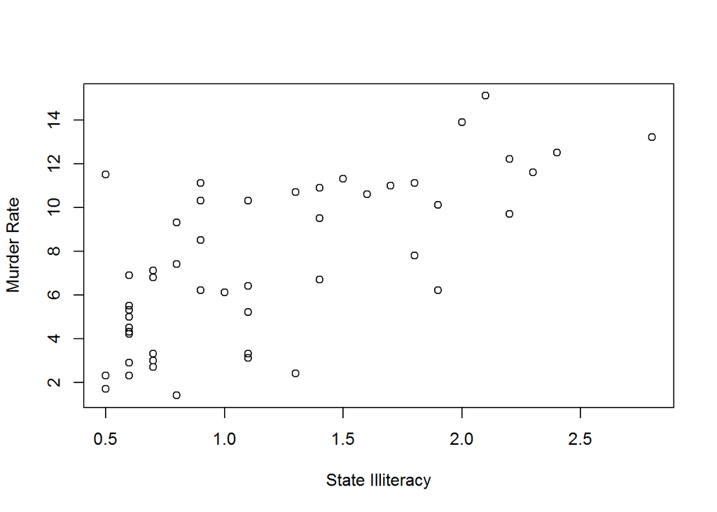

```r
plot(new.state$Illiteracy, new.state$Murder, xlab="State Illiteracy", ylab="Murder Rate")
```

i.) The plot function has an optional argument, type, that controls what type of plot is made (points, lines, etc). In particular, type = ’n’ plots nothing, but sets up and draws axes and axis labels. Use this to generate a scatterplot of Illiteracy and Murder, but with the state abbreviations labeling the points, instead of the default plotting character.

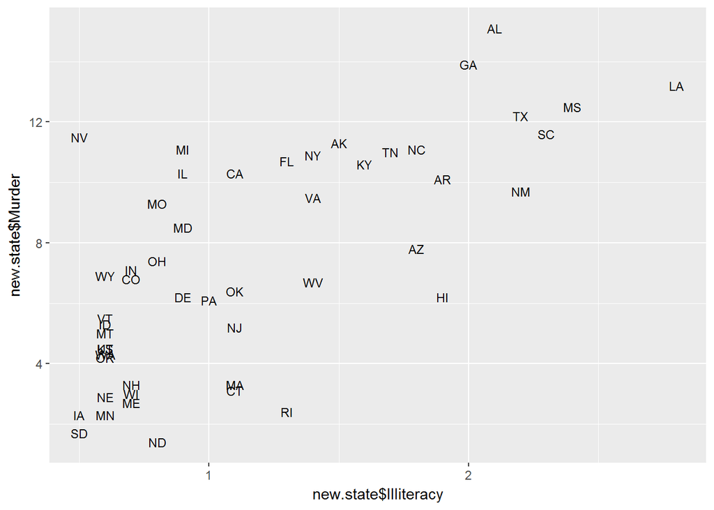

```r
ggplot(new.state, aes(x=new.state$Illiteracy, y=new.state$Murder)) + geom_text(aes(label=state.abb),size=3)
```

j.) Write a function is.min that returns a logical vector identifying the minimum values. Write another function (call it mins) that calls is.min and returns the numerical indices of the minimum values. Apply mins to the Illiteracy vector.

```r
is.min <- function(a) a==min(a)
mins <- function(a) which(is.min(a))
mins(new.state$Illiteracy)
```

```
## [1] 15 28 41
```